# Risk Factor Analysis

## Outcome Variable

**Outcome Variable:** ever_wasted

## Predictor Variables

**Intervention Variable:** nhh

**Adjustment Set:**

- arm
- W_mage
- meducyrs
- feducyrs
- W_mhtcm
- W_mwtkg
- W_mbmi
- W_nrooms
- impfloor
- impsan
- safeh20
- delta_W_mage
- delta_meducyrs
- delta_feducyrs
- delta_W_mhtcm
- delta_W_mwtkg
- delta_W_mbmi
- delta_W_nrooms
- delta_impfloor
- delta_impsan
- delta_safeh20

## Stratifying Variables

The analysis was stratified on these variable(s):

- agecat
- studyid
- country

## Data Summary

| agecat | studyid | country | nhh | ever_wasted | n_cell | n |
| --- | --- | --- | --- | --- | --- | --- |
| 0-24 months | ki1000108-IRC | INDIA | 3 or less | 0 | 20 | 410 |
| 0-24 months | ki1000108-IRC | INDIA | 3 or less | 1 | 38 | 410 |
| 0-24 months | ki1000108-IRC | INDIA | 4-5 | 0 | 63 | 410 |
| 0-24 months | ki1000108-IRC | INDIA | 4-5 | 1 | 95 | 410 |
| 0-24 months | ki1000108-IRC | INDIA | 6-7 | 0 | 38 | 410 |
| 0-24 months | ki1000108-IRC | INDIA | 6-7 | 1 | 69 | 410 |
| 0-24 months | ki1000108-IRC | INDIA | 8+ | 0 | 20 | 410 |
| 0-24 months | ki1000108-IRC | INDIA | 8+ | 1 | 67 | 410 |
| 0-24 months | ki1000304b-SAS-FoodSuppl | INDIA | 3 or less | 0 | 24 | 418 |
| 0-24 months | ki1000304b-SAS-FoodSuppl | INDIA | 3 or less | 1 | 14 | 418 |
| 0-24 months | ki1000304b-SAS-FoodSuppl | INDIA | 4-5 | 0 | 95 | 418 |
| 0-24 months | ki1000304b-SAS-FoodSuppl | INDIA | 4-5 | 1 | 88 | 418 |
| 0-24 months | ki1000304b-SAS-FoodSuppl | INDIA | 6-7 | 0 | 66 | 418 |
| 0-24 months | ki1000304b-SAS-FoodSuppl | INDIA | 6-7 | 1 | 61 | 418 |
| 0-24 months | ki1000304b-SAS-FoodSuppl | INDIA | 8+ | 0 | 36 | 418 |
| 0-24 months | ki1000304b-SAS-FoodSuppl | INDIA | 8+ | 1 | 34 | 418 |
| 0-24 months | ki1017093-NIH-Birth | BANGLADESH | 3 or less | 0 | 58 | 624 |
| 0-24 months | ki1017093-NIH-Birth | BANGLADESH | 3 or less | 1 | 57 | 624 |
| 0-24 months | ki1017093-NIH-Birth | BANGLADESH | 4-5 | 0 | 134 | 624 |
| 0-24 months | ki1017093-NIH-Birth | BANGLADESH | 4-5 | 1 | 129 | 624 |
| 0-24 months | ki1017093-NIH-Birth | BANGLADESH | 6-7 | 0 | 72 | 624 |
| 0-24 months | ki1017093-NIH-Birth | BANGLADESH | 6-7 | 1 | 69 | 624 |
| 0-24 months | ki1017093-NIH-Birth | BANGLADESH | 8+ | 0 | 62 | 624 |
| 0-24 months | ki1017093-NIH-Birth | BANGLADESH | 8+ | 1 | 43 | 624 |
| 0-24 months | ki1017093b-PROVIDE | BANGLADESH | 3 or less | 0 | 98 | 700 |
| 0-24 months | ki1017093b-PROVIDE | BANGLADESH | 3 or less | 1 | 42 | 700 |
| 0-24 months | ki1017093b-PROVIDE | BANGLADESH | 4-5 | 0 | 211 | 700 |
| 0-24 months | ki1017093b-PROVIDE | BANGLADESH | 4-5 | 1 | 111 | 700 |
| 0-24 months | ki1017093b-PROVIDE | BANGLADESH | 6-7 | 0 | 94 | 700 |
| 0-24 months | ki1017093b-PROVIDE | BANGLADESH | 6-7 | 1 | 57 | 700 |

[output cut: 114 more lines]

The following strata were considered:

- agecat: 0-24 months, studyid: ki1000108-IRC, country: INDIA
- agecat: 0-24 months, studyid: ki1000304b-SAS-FoodSuppl, country: INDIA
- agecat: 0-24 months, studyid: ki1017093-NIH-Birth, country: BANGLADESH
- agecat: 0-24 months, studyid: ki1017093b-PROVIDE, country: BANGLADESH
- agecat: 0-24 months, studyid: ki1017093c-NIH-Crypto, country: BANGLADESH
- agecat: 0-24 months, studyid: ki1148112-LCNI-5, country: MALAWI
- agecat: 0-6 months, studyid: ki1000108-IRC, country: INDIA
- agecat: 0-6 months, studyid: ki1000304b-SAS-FoodSuppl, country: INDIA
- agecat: 0-6 months, studyid: ki1017093-NIH-Birth, country: BANGLADESH
- agecat: 0-6 months, studyid: ki1017093b-PROVIDE, country: BANGLADESH
- agecat: 0-6 months, studyid: ki1017093c-NIH-Crypto, country: BANGLADESH
- agecat: 0-6 months, studyid: ki1148112-LCNI-5, country: MALAWI
- agecat: 6-24 months, studyid: ki1000108-IRC, country: INDIA
- agecat: 6-24 months, studyid: ki1000304b-SAS-FoodSuppl, country: INDIA
- agecat: 6-24 months, studyid: ki1017093-NIH-Birth, country: BANGLADESH
- agecat: 6-24 months, studyid: ki1017093b-PROVIDE, country: BANGLADESH
- agecat: 6-24 months, studyid: ki1017093c-NIH-Crypto, country: BANGLADESH
- agecat: 6-24 months, studyid: ki1148112-LCNI-5, country: MALAWI

### Dropped Strata

Some strata were dropped due to rare outcomes:

- agecat: 0-6 months, studyid: ki1000304b-SAS-FoodSuppl, country: INDIA
- agecat: 0-6 months, studyid: ki1148112-LCNI-5, country: MALAWI

## Methods Detail

We’re interested in the causal parameters $E[Y_a]$ for all values of $a \in \mathcal{A}$. These parameters represent the mean outcome if, possibly contrary to fact, we intervened to set all units to have $A=a$. Under the randomization and positivity assumptions, these are identified by the statistical parameters $\psi_a=E_W[E_{Y|A,W}(Y|A=a,W)]$. In addition, we’re interested in the mean of $Y$, $E[Y]$ under no intervention (the observed mean). We will estimate these parameters by using SuperLearner to fit the relevant likelihood factors – $E_{Y|A,W}(Y|A=a,W)$ and $p(A=a|W)$, and then updating our likelihood fit using a joint TMLE.

For unadjusted analyses ($W=\{\}$), initial likelihoods were estimated using Lrnr_glm to estimate the simple $E(Y|A)$ and Lrnr_mean to estimate $p(A)$. For adjusted analyses, a small library containing Lrnr_glmnet, Lrnr_xgboost, and Lrnr_mean was used.

Having estimated these parameters, we will then use the delta method to estimate relative risks and attributable risks relative to a prespecified baseline level of $A$.

# Results Detail

## Results Plots

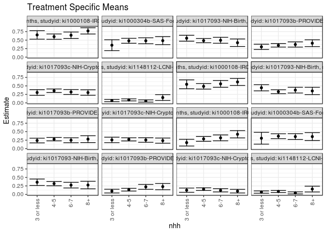

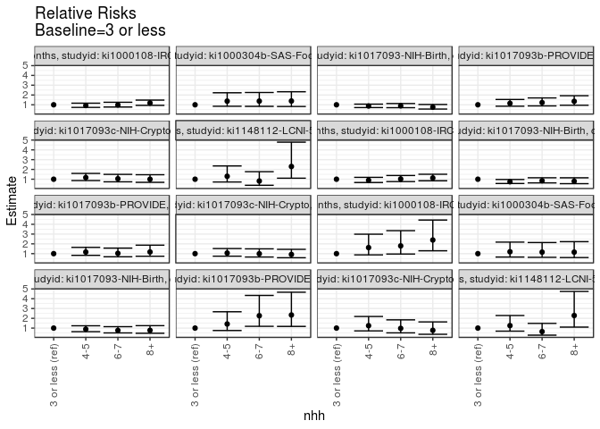

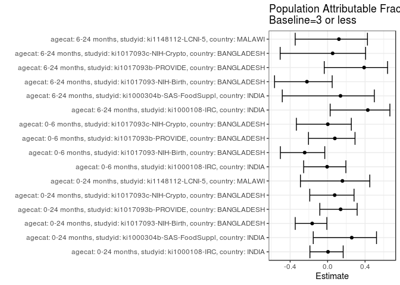

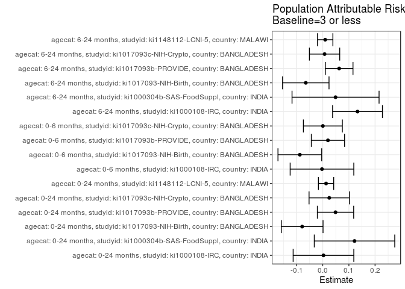

## Results Table

### Parameter: TSM

| agecat | studyid | country | intervention_level | baseline_level | estimate | ci_lower | ci_upper |
| --- | --- | --- | --- | --- | --- | --- | --- |
| 0-24 months | ki1000108-IRC | INDIA | 3 or less | NA | 0.6532312 | 0.5286324 | 0.7778299 |
| 0-24 months | ki1000108-IRC | INDIA | 4-5 | NA | 0.6028916 | 0.5247697 | 0.6810135 |
| 0-24 months | ki1000108-IRC | INDIA | 6-7 | NA | 0.6428813 | 0.5471997 | 0.7385628 |
| 0-24 months | ki1000108-IRC | INDIA | 8+ | NA | 0.7710999 | 0.6796240 | 0.8625759 |
| 0-24 months | ki1000304b-SAS-FoodSuppl | INDIA | 3 or less | NA | 0.3498263 | 0.1892533 | 0.5103994 |
| 0-24 months | ki1000304b-SAS-FoodSuppl | INDIA | 4-5 | NA | 0.4802066 | 0.4073010 | 0.5531123 |
| 0-24 months | ki1000304b-SAS-FoodSuppl | INDIA | 6-7 | NA | 0.4808052 | 0.3932472 | 0.5683631 |
| 0-24 months | ki1000304b-SAS-FoodSuppl | INDIA | 8+ | NA | 0.4844966 | 0.3665765 | 0.6024167 |
| 0-24 months | ki1017093-NIH-Birth | BANGLADESH | 3 or less | NA | 0.5561696 | 0.4690153 | 0.6433238 |
| 0-24 months | ki1017093-NIH-Birth | BANGLADESH | 4-5 | NA | 0.4847292 | 0.4227692 | 0.5466893 |
| 0-24 months | ki1017093-NIH-Birth | BANGLADESH | 6-7 | NA | 0.4952559 | 0.4077255 | 0.5827863 |
| 0-24 months | ki1017093-NIH-Birth | BANGLADESH | 8+ | NA | 0.4231418 | 0.3134153 | 0.5328684 |
| 0-24 months | ki1017093b-PROVIDE | BANGLADESH | 3 or less | NA | 0.3025681 | 0.2256474 | 0.3794887 |
| 0-24 months | ki1017093b-PROVIDE | BANGLADESH | 4-5 | NA | 0.3472744 | 0.2950409 | 0.3995079 |
| 0-24 months | ki1017093b-PROVIDE | BANGLADESH | 6-7 | NA | 0.3706631 | 0.2942110 | 0.4471152 |
| 0-24 months | ki1017093b-PROVIDE | BANGLADESH | 8+ | NA | 0.4089855 | 0.3083623 | 0.5096088 |
| 0-24 months | ki1017093c-NIH-Crypto | BANGLADESH | 3 or less | NA | 0.3048720 | 0.2214369 | 0.3883072 |
| 0-24 months | ki1017093c-NIH-Crypto | BANGLADESH | 4-5 | NA | 0.3569073 | 0.3056178 | 0.4081968 |
| 0-24 months | ki1017093c-NIH-Crypto | BANGLADESH | 6-7 | NA | 0.3197669 | 0.2475560 | 0.3919777 |
| 0-24 months | ki1017093c-NIH-Crypto | BANGLADESH | 8+ | NA | 0.3039768 | 0.2231899 | 0.3847637 |
| 0-24 months | ki1148112-LCNI-5 | MALAWI | 3 or less | NA | 0.0680146 | 0.0349199 | 0.1011092 |
| 0-24 months | ki1148112-LCNI-5 | MALAWI | 4-5 | NA | 0.0884126 | 0.0581808 | 0.1186443 |
| 0-24 months | ki1148112-LCNI-5 | MALAWI | 6-7 | NA | 0.0555979 | 0.0222732 | 0.0889225 |
| 0-24 months | ki1148112-LCNI-5 | MALAWI | 8+ | NA | 0.1563552 | 0.0706245 | 0.2420859 |
| 0-6 months | ki1000108-IRC | INDIA | 3 or less | NA | 0.5467663 | 0.4162165 | 0.6773161 |
| 0-6 months | ki1000108-IRC | INDIA | 4-5 | NA | 0.4863154 | 0.4057558 | 0.5668751 |
| 0-6 months | ki1000108-IRC | INDIA | 6-7 | NA | 0.5598474 | 0.4599643 | 0.6597305 |
| 0-6 months | ki1000108-IRC | INDIA | 8+ | NA | 0.6157736 | 0.5120437 | 0.7195035 |
| 0-6 months | ki1017093-NIH-Birth | BANGLADESH | 3 or less | NA | 0.4443223 | 0.3527264 | 0.5359181 |
| 0-6 months | ki1017093-NIH-Birth | BANGLADESH | 4-5 | NA | 0.3285650 | 0.2707735 | 0.3863564 |
| 0-6 months | ki1017093-NIH-Birth | BANGLADESH | 6-7 | NA | 0.3755999 | 0.2910068 | 0.4601930 |
| 0-6 months | ki1017093-NIH-Birth | BANGLADESH | 8+ | NA | 0.3512095 | 0.2431780 | 0.4592410 |
| 0-6 months | ki1017093b-PROVIDE | BANGLADESH | 3 or less | NA | 0.2386150 | 0.1686777 | 0.3085523 |
| 0-6 months | ki1017093b-PROVIDE | BANGLADESH | 4-5 | NA | 0.2777775 | 0.2279594 | 0.3275955 |
| 0-6 months | ki1017093b-PROVIDE | BANGLADESH | 6-7 | NA | 0.2466022 | 0.1735795 | 0.3196248 |
| 0-6 months | ki1017093b-PROVIDE | BANGLADESH | 8+ | NA | 0.2795947 | 0.1783956 | 0.3807938 |
| 0-6 months | ki1017093c-NIH-Crypto | BANGLADESH | 3 or less | NA | 0.2567039 | 0.1760696 | 0.3373381 |
| 0-6 months | ki1017093c-NIH-Crypto | BANGLADESH | 4-5 | NA | 0.2728367 | 0.2259815 | 0.3196919 |
| 0-6 months | ki1017093c-NIH-Crypto | BANGLADESH | 6-7 | NA | 0.2541905 | 0.1871094 | 0.3212716 |
| 0-6 months | ki1017093c-NIH-Crypto | BANGLADESH | 8+ | NA | 0.2355132 | 0.1593722 | 0.3116541 |
| 6-24 months | ki1000108-IRC | INDIA | 3 or less | NA | 0.1768100 | 0.0778474 | 0.2757727 |
| 6-24 months | ki1000108-IRC | INDIA | 4-5 | NA | 0.2864946 | 0.2154945 | 0.3574946 |
| 6-24 months | ki1000108-IRC | INDIA | 6-7 | NA | 0.3170917 | 0.2300429 | 0.4041406 |
| 6-24 months | ki1000108-IRC | INDIA | 8+ | NA | 0.4233206 | 0.3153225 | 0.5313187 |
| 6-24 months | ki1000304b-SAS-FoodSuppl | INDIA | 3 or less | NA | 0.3067129 | 0.1329824 | 0.4804435 |
| 6-24 months | ki1000304b-SAS-FoodSuppl | INDIA | 4-5 | NA | 0.3660093 | 0.2938646 | 0.4381539 |
| 6-24 months | ki1000304b-SAS-FoodSuppl | INDIA | 6-7 | NA | 0.3543456 | 0.2692258 | 0.4394655 |
| 6-24 months | ki1000304b-SAS-FoodSuppl | INDIA | 8+ | NA | 0.3543392 | 0.2381814 | 0.4704971 |
| 6-24 months | ki1017093-NIH-Birth | BANGLADESH | 3 or less | NA | 0.3580823 | 0.2621273 | 0.4540372 |
| 6-24 months | ki1017093-NIH-Birth | BANGLADESH | 4-5 | NA | 0.3178726 | 0.2546460 | 0.3810992 |
| 6-24 months | ki1017093-NIH-Birth | BANGLADESH | 6-7 | NA | 0.2725671 | 0.1888024 | 0.3563317 |
| 6-24 months | ki1017093-NIH-Birth | BANGLADESH | 8+ | NA | 0.2755737 | 0.1643388 | 0.3868085 |
| 6-24 months | ki1017093b-PROVIDE | BANGLADESH | 3 or less | NA | 0.0982339 | 0.0428756 | 0.1535922 |
| 6-24 months | ki1017093b-PROVIDE | BANGLADESH | 4-5 | NA | 0.1392803 | 0.0992655 | 0.1792951 |
| 6-24 months | ki1017093b-PROVIDE | BANGLADESH | 6-7 | NA | 0.2224221 | 0.1504514 | 0.2943927 |
| 6-24 months | ki1017093b-PROVIDE | BANGLADESH | 8+ | NA | 0.2297665 | 0.1382528 | 0.3212803 |
| 6-24 months | ki1017093c-NIH-Crypto | BANGLADESH | 3 or less | NA | 0.1244384 | 0.0621425 | 0.1867342 |
| 6-24 months | ki1017093c-NIH-Crypto | BANGLADESH | 4-5 | NA | 0.1552938 | 0.1161536 | 0.1944340 |
| 6-24 months | ki1017093c-NIH-Crypto | BANGLADESH | 6-7 | NA | 0.1209333 | 0.0727208 | 0.1691459 |
| 6-24 months | ki1017093c-NIH-Crypto | BANGLADESH | 8+ | NA | 0.0962430 | 0.0429341 | 0.1495520 |
| 6-24 months | ki1148112-LCNI-5 | MALAWI | 3 or less | NA | 0.0688073 | 0.0351851 | 0.1024296 |
| 6-24 months | ki1148112-LCNI-5 | MALAWI | 4-5 | NA | 0.0863095 | 0.0562642 | 0.1163549 |
| 6-24 months | ki1148112-LCNI-5 | MALAWI | 6-7 | NA | 0.0441989 | 0.0142371 | 0.0741607 |
| 6-24 months | ki1148112-LCNI-5 | MALAWI | 8+ | NA | 0.1571429 | 0.0718342 | 0.2424516 |

### Parameter: E(Y)

| agecat | studyid | country | intervention_level | baseline_level | estimate | ci_lower | ci_upper |
| --- | --- | --- | --- | --- | --- | --- | --- |
| 0-24 months | ki1000108-IRC | INDIA | NA | NA | 0.6560976 | 0.6100625 | 0.7021326 |
| 0-24 months | ki1000304b-SAS-FoodSuppl | INDIA | NA | NA | 0.4712919 | 0.4233811 | 0.5192026 |
| 0-24 months | ki1017093-NIH-Birth | BANGLADESH | NA | NA | 0.4775641 | 0.4383415 | 0.5167867 |
| 0-24 months | ki1017093b-PROVIDE | BANGLADESH | NA | NA | 0.3514286 | 0.3160364 | 0.3868207 |
| 0-24 months | ki1017093c-NIH-Crypto | BANGLADESH | NA | NA | 0.3298153 | 0.2963239 | 0.3633067 |
| 0-24 months | ki1148112-LCNI-5 | MALAWI | NA | NA | 0.0807834 | 0.0620863 | 0.0994804 |
| 0-6 months | ki1000108-IRC | INDIA | NA | NA | 0.5439024 | 0.4956326 | 0.5921723 |
| 0-6 months | ki1017093-NIH-Birth | BANGLADESH | NA | NA | 0.3569132 | 0.3192325 | 0.3945938 |
| 0-6 months | ki1017093b-PROVIDE | BANGLADESH | NA | NA | 0.2585714 | 0.2261125 | 0.2910304 |
| 0-6 months | ki1017093c-NIH-Crypto | BANGLADESH | NA | NA | 0.2572559 | 0.2261171 | 0.2883948 |
| 6-24 months | ki1000108-IRC | INDIA | NA | NA | 0.3097561 | 0.2649438 | 0.3545684 |
| 6-24 months | ki1000304b-SAS-FoodSuppl | INDIA | NA | NA | 0.3557214 | 0.3088651 | 0.4025777 |
| 6-24 months | ki1017093-NIH-Birth | BANGLADESH | NA | NA | 0.2933579 | 0.2549918 | 0.3317241 |
| 6-24 months | ki1017093b-PROVIDE | BANGLADESH | NA | NA | 0.1609756 | 0.1319065 | 0.1900447 |
| 6-24 months | ki1017093c-NIH-Crypto | BANGLADESH | NA | NA | 0.1315069 | 0.1069744 | 0.1560393 |
| 6-24 months | ki1148112-LCNI-5 | MALAWI | NA | NA | 0.0782609 | 0.0596958 | 0.0968259 |

### Parameter: RR

| agecat | studyid | country | intervention_level | baseline_level | estimate | ci_lower | ci_upper |
| --- | --- | --- | --- | --- | --- | --- | --- |
| 0-24 months | ki1000108-IRC | INDIA | 3 or less | 3 or less | 1.0000000 | 1.0000000 | 1.0000000 |
| 0-24 months | ki1000108-IRC | INDIA | 4-5 | 3 or less | 0.9229375 | 0.7327510 | 1.1624872 |
| 0-24 months | ki1000108-IRC | INDIA | 6-7 | 3 or less | 0.9841558 | 0.7725472 | 1.2537262 |
| 0-24 months | ki1000108-IRC | INDIA | 8+ | 3 or less | 1.1804396 | 0.9427324 | 1.4780839 |
| 0-24 months | ki1000304b-SAS-FoodSuppl | INDIA | 3 or less | 3 or less | 1.0000000 | 1.0000000 | 1.0000000 |
| 0-24 months | ki1000304b-SAS-FoodSuppl | INDIA | 4-5 | 3 or less | 1.3727001 | 0.8462197 | 2.2267331 |
| 0-24 months | ki1000304b-SAS-FoodSuppl | INDIA | 6-7 | 3 or less | 1.3744110 | 0.8388487 | 2.2519027 |
| 0-24 months | ki1000304b-SAS-FoodSuppl | INDIA | 8+ | 3 or less | 1.3849632 | 0.8235833 | 2.3289972 |
| 0-24 months | ki1017093-NIH-Birth | BANGLADESH | 3 or less | 3 or less | 1.0000000 | 1.0000000 | 1.0000000 |
| 0-24 months | ki1017093-NIH-Birth | BANGLADESH | 4-5 | 3 or less | 0.8715494 | 0.7123360 | 1.0663484 |
| 0-24 months | ki1017093-NIH-Birth | BANGLADESH | 6-7 | 3 or less | 0.8904764 | 0.7033217 | 1.1274331 |
| 0-24 months | ki1017093-NIH-Birth | BANGLADESH | 8+ | 3 or less | 0.7608144 | 0.5619427 | 1.0300669 |
| 0-24 months | ki1017093b-PROVIDE | BANGLADESH | 3 or less | 3 or less | 1.0000000 | 1.0000000 | 1.0000000 |
| 0-24 months | ki1017093b-PROVIDE | BANGLADESH | 4-5 | 3 or less | 1.1477563 | 0.8541126 | 1.5423545 |
| 0-24 months | ki1017093b-PROVIDE | BANGLADESH | 6-7 | 3 or less | 1.2250569 | 0.8835895 | 1.6984859 |
| 0-24 months | ki1017093b-PROVIDE | BANGLADESH | 8+ | 3 or less | 1.3517141 | 0.9498156 | 1.9236693 |
| 0-24 months | ki1017093c-NIH-Crypto | BANGLADESH | 3 or less | 3 or less | 1.0000000 | 1.0000000 | 1.0000000 |
| 0-24 months | ki1017093c-NIH-Crypto | BANGLADESH | 4-5 | 3 or less | 1.1706790 | 0.8600056 | 1.5935819 |
| 0-24 months | ki1017093c-NIH-Crypto | BANGLADESH | 6-7 | 3 or less | 1.0488561 | 0.7358925 | 1.4949182 |
| 0-24 months | ki1017093c-NIH-Crypto | BANGLADESH | 8+ | 3 or less | 0.9970637 | 0.6813736 | 1.4590176 |
| 0-24 months | ki1148112-LCNI-5 | MALAWI | 3 or less | 3 or less | 1.0000000 | 1.0000000 | 1.0000000 |
| 0-24 months | ki1148112-LCNI-5 | MALAWI | 4-5 | 3 or less | 1.2999066 | 0.7172457 | 2.3558972 |
| 0-24 months | ki1148112-LCNI-5 | MALAWI | 6-7 | 3 or less | 0.8174406 | 0.3776426 | 1.7694222 |
| 0-24 months | ki1148112-LCNI-5 | MALAWI | 8+ | 3 or less | 2.2988494 | 1.1044452 | 4.7849443 |
| 0-6 months | ki1000108-IRC | INDIA | 3 or less | 3 or less | 1.0000000 | 1.0000000 | 1.0000000 |
| 0-6 months | ki1000108-IRC | INDIA | 4-5 | 3 or less | 0.8894393 | 0.6649237 | 1.1897640 |
| 0-6 months | ki1000108-IRC | INDIA | 6-7 | 3 or less | 1.0239246 | 0.7599024 | 1.3796791 |
| 0-6 months | ki1000108-IRC | INDIA | 8+ | 3 or less | 1.1262099 | 0.8407721 | 1.5085523 |
| 0-6 months | ki1017093-NIH-Birth | BANGLADESH | 3 or less | 3 or less | 1.0000000 | 1.0000000 | 1.0000000 |
| 0-6 months | ki1017093-NIH-Birth | BANGLADESH | 4-5 | 3 or less | 0.7394745 | 0.5638068 | 0.9698756 |
| 0-6 months | ki1017093-NIH-Birth | BANGLADESH | 6-7 | 3 or less | 0.8453322 | 0.6230536 | 1.1469101 |
| 0-6 months | ki1017093-NIH-Birth | BANGLADESH | 8+ | 3 or less | 0.7904388 | 0.5457009 | 1.1449375 |
| 0-6 months | ki1017093b-PROVIDE | BANGLADESH | 3 or less | 3 or less | 1.0000000 | 1.0000000 | 1.0000000 |
| 0-6 months | ki1017093b-PROVIDE | BANGLADESH | 4-5 | 3 or less | 1.1641244 | 0.8254528 | 1.6417480 |
| 0-6 months | ki1017093b-PROVIDE | BANGLADESH | 6-7 | 3 or less | 1.0334732 | 0.6815797 | 1.5670462 |
| 0-6 months | ki1017093b-PROVIDE | BANGLADESH | 8+ | 3 or less | 1.1717400 | 0.7357383 | 1.8661182 |
| 0-6 months | ki1017093c-NIH-Crypto | BANGLADESH | 3 or less | 3 or less | 1.0000000 | 1.0000000 | 1.0000000 |
| 0-6 months | ki1017093c-NIH-Crypto | BANGLADESH | 4-5 | 3 or less | 1.0628461 | 0.7429703 | 1.5204401 |
| 0-6 months | ki1017093c-NIH-Crypto | BANGLADESH | 6-7 | 3 or less | 0.9902089 | 0.6569616 | 1.4924978 |
| 0-6 months | ki1017093c-NIH-Crypto | BANGLADESH | 8+ | 3 or less | 0.9174507 | 0.5845693 | 1.4398906 |
| 6-24 months | ki1000108-IRC | INDIA | 3 or less | 3 or less | 1.0000000 | 1.0000000 | 1.0000000 |
| 6-24 months | ki1000108-IRC | INDIA | 4-5 | 3 or less | 1.6203524 | 0.8781246 | 2.9899425 |
| 6-24 months | ki1000108-IRC | INDIA | 6-7 | 3 or less | 1.7934034 | 0.9604265 | 3.3488206 |
| 6-24 months | ki1000108-IRC | INDIA | 8+ | 3 or less | 2.3942110 | 1.2929502 | 4.4334625 |
| 6-24 months | ki1000304b-SAS-FoodSuppl | INDIA | 3 or less | 3 or less | 1.0000000 | 1.0000000 | 1.0000000 |
| 6-24 months | ki1000304b-SAS-FoodSuppl | INDIA | 4-5 | 3 or less | 1.1933285 | 0.6542613 | 2.1765506 |
| 6-24 months | ki1000304b-SAS-FoodSuppl | INDIA | 6-7 | 3 or less | 1.1553006 | 0.6243894 | 2.1376396 |
| 6-24 months | ki1000304b-SAS-FoodSuppl | INDIA | 8+ | 3 or less | 1.1552797 | 0.6002396 | 2.2235637 |
| 6-24 months | ki1017093-NIH-Birth | BANGLADESH | 3 or less | 3 or less | 1.0000000 | 1.0000000 | 1.0000000 |
| 6-24 months | ki1017093-NIH-Birth | BANGLADESH | 4-5 | 3 or less | 0.8877084 | 0.6364666 | 1.2381266 |
| 6-24 months | ki1017093-NIH-Birth | BANGLADESH | 6-7 | 3 or less | 0.7611856 | 0.5065215 | 1.1438872 |
| 6-24 months | ki1017093-NIH-Birth | BANGLADESH | 8+ | 3 or less | 0.7695820 | 0.4739281 | 1.2496758 |
| 6-24 months | ki1017093b-PROVIDE | BANGLADESH | 3 or less | 3 or less | 1.0000000 | 1.0000000 | 1.0000000 |
| 6-24 months | ki1017093b-PROVIDE | BANGLADESH | 4-5 | 3 or less | 1.4178438 | 0.7528813 | 2.6701168 |
| 6-24 months | ki1017093b-PROVIDE | BANGLADESH | 6-7 | 3 or less | 2.2642091 | 1.1817440 | 4.3382010 |
| 6-24 months | ki1017093b-PROVIDE | BANGLADESH | 8+ | 3 or less | 2.3389742 | 1.1732801 | 4.6628252 |
| 6-24 months | ki1017093c-NIH-Crypto | BANGLADESH | 3 or less | 3 or less | 1.0000000 | 1.0000000 | 1.0000000 |
| 6-24 months | ki1017093c-NIH-Crypto | BANGLADESH | 4-5 | 3 or less | 1.2479579 | 0.7124813 | 2.1858805 |
| 6-24 months | ki1017093c-NIH-Crypto | BANGLADESH | 6-7 | 3 or less | 0.9718333 | 0.5123245 | 1.8434803 |
| 6-24 months | ki1017093c-NIH-Crypto | BANGLADESH | 8+ | 3 or less | 0.7734194 | 0.3664516 | 1.6323509 |
| 6-24 months | ki1148112-LCNI-5 | MALAWI | 3 or less | 3 or less | 1.0000000 | 1.0000000 | 1.0000000 |
| 6-24 months | ki1148112-LCNI-5 | MALAWI | 4-5 | 3 or less | 1.2543651 | 0.6884364 | 2.2855150 |
| 6-24 months | ki1148112-LCNI-5 | MALAWI | 6-7 | 3 or less | 0.6423573 | 0.2785228 | 1.4814690 |
| 6-24 months | ki1148112-LCNI-5 | MALAWI | 8+ | 3 or less | 2.2838095 | 1.1001482 | 4.7409848 |

### Parameter: PAR

| agecat | studyid | country | intervention_level | baseline_level | estimate | ci_lower | ci_upper |
| --- | --- | --- | --- | --- | --- | --- | --- |
| 0-24 months | ki1000108-IRC | INDIA | 3 or less | NA | 0.0028664 | -0.1130140 | 0.1187467 |
| 0-24 months | ki1000304b-SAS-FoodSuppl | INDIA | 3 or less | NA | 0.1214655 | -0.0322836 | 0.2752147 |
| 0-24 months | ki1017093-NIH-Birth | BANGLADESH | 3 or less | NA | -0.0786055 | -0.1583761 | 0.0011652 |
| 0-24 months | ki1017093b-PROVIDE | BANGLADESH | 3 or less | NA | 0.0488605 | -0.0205399 | 0.1182609 |
| 0-24 months | ki1017093c-NIH-Crypto | BANGLADESH | 3 or less | NA | 0.0249433 | -0.0522359 | 0.1021225 |
| 0-24 months | ki1148112-LCNI-5 | MALAWI | 3 or less | NA | 0.0127688 | -0.0163967 | 0.0419343 |
| 0-6 months | ki1000108-IRC | INDIA | 3 or less | NA | -0.0028638 | -0.1244422 | 0.1187145 |
| 0-6 months | ki1017093-NIH-Birth | BANGLADESH | 3 or less | NA | -0.0874091 | -0.1709709 | -0.0038472 |
| 0-6 months | ki1017093b-PROVIDE | BANGLADESH | 3 or less | NA | 0.0199565 | -0.0436062 | 0.0835191 |
| 0-6 months | ki1017093c-NIH-Crypto | BANGLADESH | 3 or less | NA | 0.0005521 | -0.0738363 | 0.0749405 |
| 6-24 months | ki1000108-IRC | INDIA | 3 or less | NA | 0.1329461 | 0.0377636 | 0.2281285 |
| 6-24 months | ki1000304b-SAS-FoodSuppl | INDIA | 3 or less | NA | 0.0490085 | -0.1172521 | 0.2152690 |
| 6-24 months | ki1017093-NIH-Birth | BANGLADESH | 3 or less | NA | -0.0647243 | -0.1535069 | 0.0240582 |
| 6-24 months | ki1017093b-PROVIDE | BANGLADESH | 3 or less | NA | 0.0627417 | 0.0098344 | 0.1156491 |
| 6-24 months | ki1017093c-NIH-Crypto | BANGLADESH | 3 or less | NA | 0.0070685 | -0.0508279 | 0.0649649 |
| 6-24 months | ki1148112-LCNI-5 | MALAWI | 3 or less | NA | 0.0094535 | -0.0199207 | 0.0388278 |

### Parameter: PAF

| agecat | studyid | country | intervention_level | baseline_level | estimate | ci_lower | ci_upper |
| --- | --- | --- | --- | --- | --- | --- | --- |
| 0-24 months | ki1000108-IRC | INDIA | 3 or less | NA | 0.0043688 | -0.1888861 | 0.1662099 |
| 0-24 months | ki1000304b-SAS-FoodSuppl | INDIA | 3 or less | NA | 0.2577289 | -0.1531716 | 0.5222165 |
| 0-24 months | ki1017093-NIH-Birth | BANGLADESH | 3 or less | NA | -0.1645967 | -0.3455959 | -0.0079441 |
| 0-24 months | ki1017093b-PROVIDE | BANGLADESH | 3 or less | NA | 0.1390340 | -0.0830092 | 0.3155529 |
| 0-24 months | ki1017093c-NIH-Crypto | BANGLADESH | 3 or less | NA | 0.0756280 | -0.1906038 | 0.2823276 |
| 0-24 months | ki1148112-LCNI-5 | MALAWI | 3 or less | NA | 0.1580623 | -0.2901763 | 0.4505719 |
| 0-6 months | ki1000108-IRC | INDIA | 3 or less | NA | -0.0052654 | -0.2556002 | 0.1951591 |
| 0-6 months | ki1017093-NIH-Birth | BANGLADESH | 3 or less | NA | -0.2449029 | -0.5042705 | -0.0302557 |
| 0-6 months | ki1017093b-PROVIDE | BANGLADESH | 3 or less | NA | 0.0771797 | -0.2041238 | 0.2927660 |
| 0-6 months | ki1017093c-NIH-Crypto | BANGLADESH | 3 or less | NA | 0.0021459 | -0.3332702 | 0.2531801 |
| 6-24 months | ki1000108-IRC | INDIA | 3 or less | NA | 0.4291959 | 0.0272825 | 0.6650443 |
| 6-24 months | ki1000304b-SAS-FoodSuppl | INDIA | 3 or less | NA | 0.1377720 | -0.4839530 | 0.4990158 |
| 6-24 months | ki1017093-NIH-Birth | BANGLADESH | 3 or less | NA | -0.2206326 | -0.5666501 | 0.0489619 |
| 6-24 months | ki1017093b-PROVIDE | BANGLADESH | 3 or less | NA | 0.3897592 | -0.0358425 | 0.6404918 |
| 6-24 months | ki1017093c-NIH-Crypto | BANGLADESH | 3 or less | NA | 0.0537500 | -0.5066093 | 0.4056926 |
| 6-24 months | ki1148112-LCNI-5 | MALAWI | 3 or less | NA | 0.1207951 | -0.3459615 | 0.4256884 |